# CUDA research

```python
import matplotlib.pyplot as plt
%matplotlib inline
```

В рамках работы было принято решение использовать технологию nvdia CUDA чтобы выполнить программу в несколько потоков на видеокарте и сравнить результат с однопоточным режимом на CPU. Видеокарта позволяет запускать огромное множество потоков, что было оптимально для этой задачи. Я прогнала программу на разных объемах данных и получила следующие результаты:

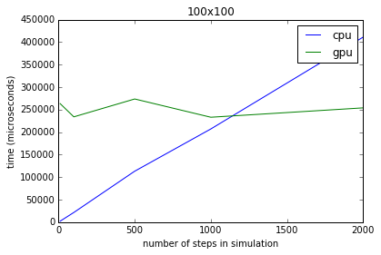

```python
num_steps = [10, 100, 500, 1000, 2000]
gpu = [263363, 233950, 273662, 233063, 253890]
cpu = [2165, 21509, 113211, 207043, 410952]
plt.plot(num_steps, cpu, label = 'cpu')
plt.plot(num_steps, gpu, label = 'gpu')
plt.xlabel('number of steps in simulation')
plt.ylabel('time (microseconds)')
plt.title('100x100')
plt.legend()
```

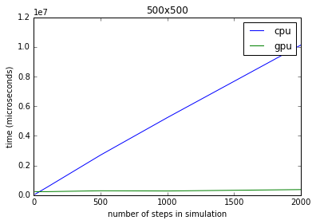

```python
num_steps = [10, 100, 500, 1000, 2000]
gpu = [235687 , 236630 , 293901 , 280989 , 374887 ]
cpu = [58768 , 533246 , 2700179 , 5227636 , 10123146 ]
plt.plot(num_steps, cpu, label = 'cpu')
plt.plot(num_steps, gpu, label = 'gpu')
plt.xlabel('number of steps in simulation')
plt.ylabel('time (microseconds)')
plt.title('500x500')
plt.legend()
```

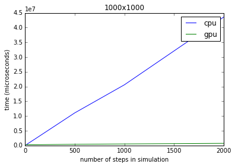

```python
num_steps = [10, 100, 500, 1000, 2000]
gpu = [254533, 267670, 402957, 521785, 729536]
cpu = [235269, 2193037, 11051254, 20584450, 43582225]
plt.plot(num_steps, cpu, label = 'cpu')
plt.plot(num_steps, gpu, label = 'gpu')
plt.xlabel('number of steps in simulation')
plt.ylabel('time (microseconds)')
plt.title('1000x1000')
plt.legend()
```

Как видно из графиков, время работы видеокарты начинается с определенного минимума и дальше растет намного медленнее, чем время выполнения на центральном процессоре. Объяснение этому - медленные процессы выделения памяти на видеокарте и их копирование по шине. Однако когда они скопированы, работа идет на порядки быстрее. Каждая клетка обсчитывается своим потоком, которые группируются в блоки по 100. Как возможный вариант дальнейшей оптимизации я рассматриваю использовать разделяемую память для потоков. Так как каждый из них читает для своей клетки 8 ее соседок, получается что одни и те же клетки будут прочитаны несколькими потоками много раз. Разделяемая память позволила бы оптимизировать эту проблему в рамках блока. Но для эффективного использования этой техники пришлось бы упорядочивать клетки в массиве не линейно слева-направо, а с учетом вертикального расположения тоже.